# Visualizing CausalImpact Output with ggplot

Author

Tim Wilson

## Purpose

The CausalImpact R package generates a ready-made plot of its results. But, sometimes, it is useful to only display a subset of the results, as well as to adjust the specifics of the visualization. There are *some* limited adjustments that can be made without the approach outlined in this document, but those are often too limiting to meet the needs of a specific visualization.

The approach here is pretty simple:

1. Extract the results of the model and drop them into a data frame
2. Use that data frame and **ggplot** to do various visualizations.

## Getting Started

Load the relevant packages.

```r
if (!require("pacman")) install.packages("pacman")
pacman::p_load(tidyverse,
               lubridate,    # Tweaking dates
               scales,       # Handy for axis label formatting
               CausalImpact  # Bayesian structural time-series forecasting
)
```

This next part is artificial, in that we’re just going to load a simple dataset to use with CausalImpact. This includes a (dramatic) detectable effect at the intervention point. The sample data includes a column with a date in it. This isn’t required for CausalImpact (which can also work with data that is not daily data), but it’s awfully common for that to be useful, so it’s included in the sample here.

This dataset also does *not* include any columns with covariates…because this is not about *using* CausalImpact but, rather, just about visualizing the results, and the covariates are just an optional additional input rather than part of the output.

```r
df_input <- read_csv("sample_data.csv")
head(df_input)
```

```
# A tibble: 6 × 2
  date       value
  <date>     <dbl>
1 2023-01-19  9856
2 2023-01-20 10352
3 2023-01-21  9908
4 2023-01-22  9686
5 2023-01-23 10215
6 2023-01-24 10551
```

Run CausalImpact on the dataset and produce the default plot.

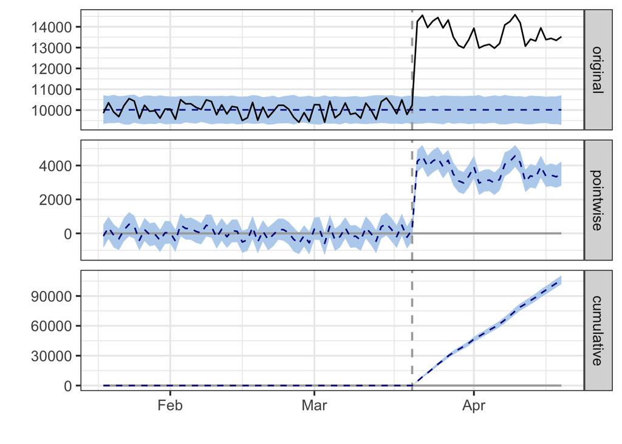

```r
impact <- CausalImpact(df_input,
                       pre.period = as.Date(c("2023-01-19", "2023-03-20")),
                       post.period = as.Date(c("2023-03-21", "2023-04-18")))

plot(impact)
```

The default plot includes three plots. A subset of these can be displayed instead pretty easily:

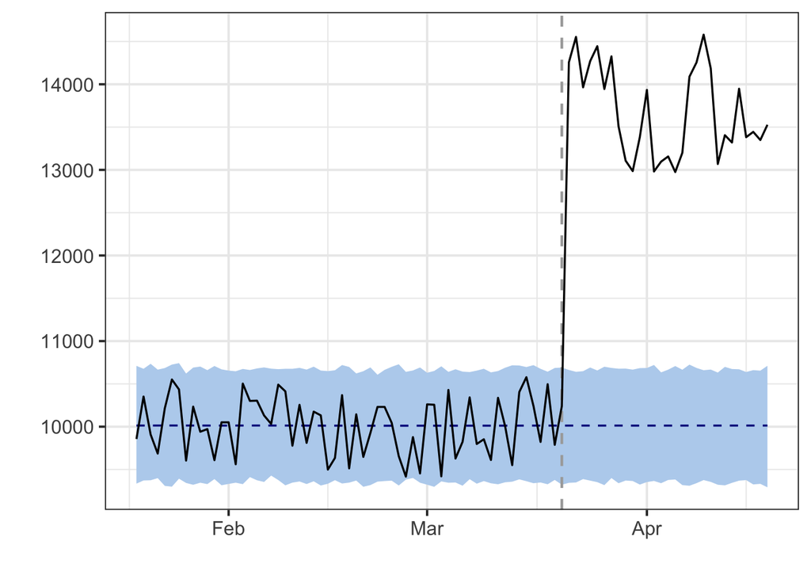

```r
# Show just one of the plots
plot(impact, "original")
```

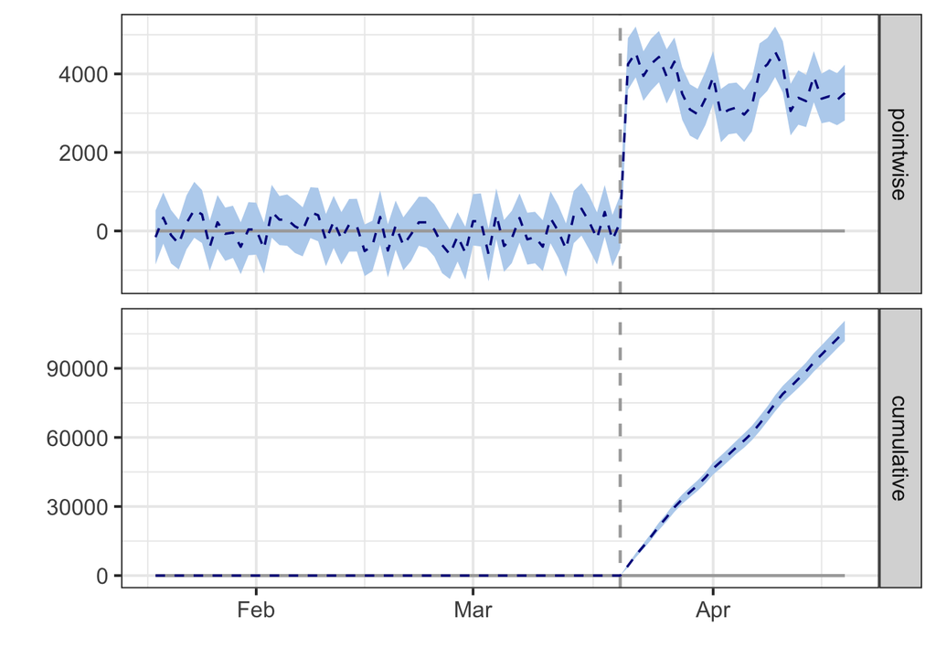

```r
# Show two of the plots
plot(impact, c("pointwise", "cumulative"))
```

And, we can even add ggplot-y elements, which can do quite a bit.

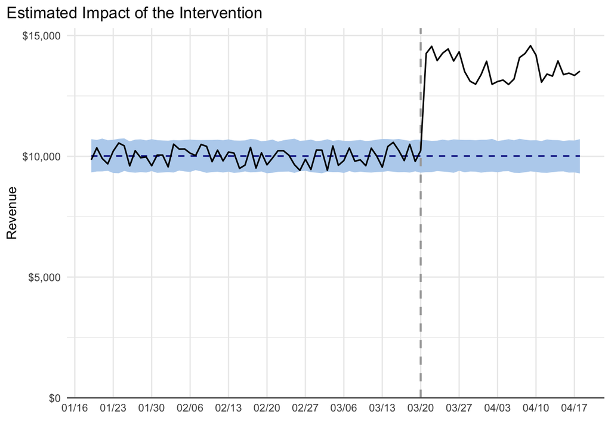

```r
# Work with a single chart
plot(impact, "original") +
  # Control the y-axis more to force a 0-based axis and to add commas to the #s
  scale_y_continuous(expand = c(0,0), limits = ~ c(0, max(.x) * 1.05), label = dollar) +
  # Change the x-axis to...why not...show weekly dates
  scale_x_date(date_breaks = "1 week", date_labels = "%m/%d") +
  # Add a title and a y-axis label
  labs(title = "Estimated Impact of the Intervention",
       y = "Revenue") +
  # Additional formatting with various theme-age
  theme_minimal() +
  theme(plot.title.position = "plot",
        axis.line.x = element_line(color = "gray30"),
        panel.grid.minor.x = element_blank())
```

That’s quite a bit. But, what if I wanted to change the lines or shaded areas on the chart itself? That, as far as I know, is a lot tougher, as those are actually defined within the plot–not things that can be simply changed “additively.”

If we want to change the characteristics of the plotted data elements themselves, this, in theory, is doable by working with `.params` arguments. Details on that are [here](https://cran.r-project.org/web/packages/casebase/vignettes/customizingpopTime.html).

10 minutes of noodling didn’t get this working for me, although I’m confident that it is actually a workable approach. The challenge with this, though, is it starts to feel a little hacky–employing semi-obscure functionality to do plot retrofitting.

So, let’s quickly explore an alternative: simply plotting from the model’s data itself.

## Getting More Robustly Customized Visualizations

Start by extracting all of the values used in the plot into a single data frame. The data is in a `zoo` object called `series` inside **impact**, so we’re just going to turn that into a data frame, and we’ll pull the date values, which are populated as row names, out into their own date column.

```r
df_output <- as.data.frame(impact$series) |>
  # Go ahead and pull the rownames out as a separate date column
  rownames_to_column(var = "date") |>
  mutate(date = as.Date(date))

names(df_output)
```

```
 [1] "date"               "response"           "cum.response"
 [4] "point.pred"         "point.pred.lower"   "point.pred.upper"
 [7] "cum.pred"           "cum.pred.lower"     "cum.pred.upper"
[10] "point.effect"       "point.effect.lower" "point.effect.upper"
[13] "cum.effect"         "cum.effect.lower"   "cum.effect.upper"
```

These names may seem a little confusing at first, but this is actually a data frame with everything (except the location of the intervention) used in the default output plot.

## Define Some “Base” Formatting

This is not strictly necessary, but, often, we’re going to build a few different visualizations that have similar stylistic characteristics, so let’s define a base theme and any other “commonly used” aspects of the visuals. That way, we can tinker with those in one spot and have them propagate through all of the visuals (overriding them as necessary).

```r
# Set up the theme to use as the base for all plots
theme_custom <- theme_minimal() +
  theme(plot.title.position = "plot",
        axis.title.x = element_blank(),
        axis.line.x = element_line(color = "gray20"),
        panel.grid.major.x = element_blank())

# Define the ribbon color for all plots
ribbon_color = "#e2dcf1"

# Set a color and width for the "main line" being displayed
main_line_width = 0.8
main_line_color = "gray20"

# Set a color, width, and linetype for the "prediction line" being displayed
pred_line_width = 0.6
pred_line_color = "#00008b"
pred_line_type = "longdash"

# Intervention line
int_line_width = 0.8
int_line_color = "gray70"
int_line_type = "dotted"
```

### Original Plot

Show a custom plot of just the “original” plot.

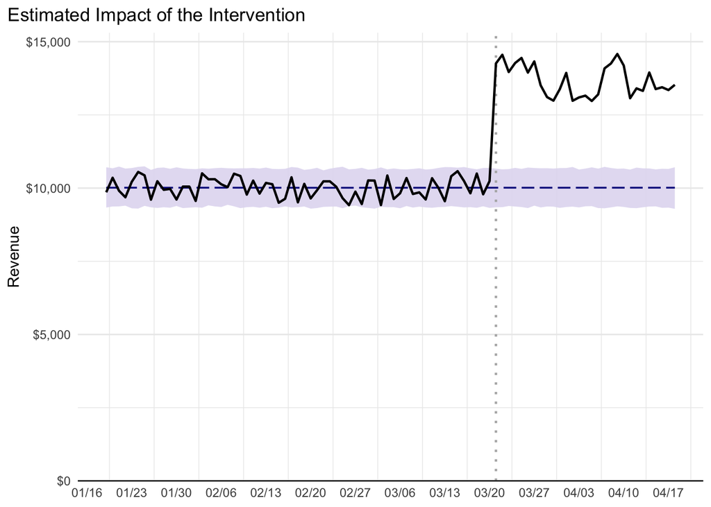

```r
gg_original <- ggplot(df_output, aes(x = date)) +
  # Add the ribbon
  geom_ribbon(mapping = aes(ymin = point.pred.lower,
                            ymax = point.pred.upper),
              alpha = 0.9,
              fill = ribbon_color) +
  # Intervention line. This is the one thing we go back to the model and pull from--
  # assuming we want to put it on the first day of the "post" period
  geom_vline(mapping = aes(xintercept = impact$model$post.period[1]),
             color = int_line_color, linetype = int_line_type, linewidth = int_line_width) +
  # Add the "prediction" line
  geom_line(mapping = aes(y = point.pred, group=1), color = pred_line_color,
            linetype = pred_line_type,
            linewidth = pred_line_width) +
  # Add the line with the actual data
  geom_line(mapping = aes(y = response, group=1), linewidth = main_line_width) +
  labs(title = "Estimated Impact of the Intervention",
       y = "Revenue") +
  scale_y_continuous(expand = c(0,0), limits = ~ c(0, max(.x) * 1.05),
                     labels = dollar) +
  scale_x_date(date_breaks = "1 week", date_labels = "%m/%d") +
  theme_custom

gg_original
```

### Pointwise Plot

Do the same thing…but for the pointwise plot.

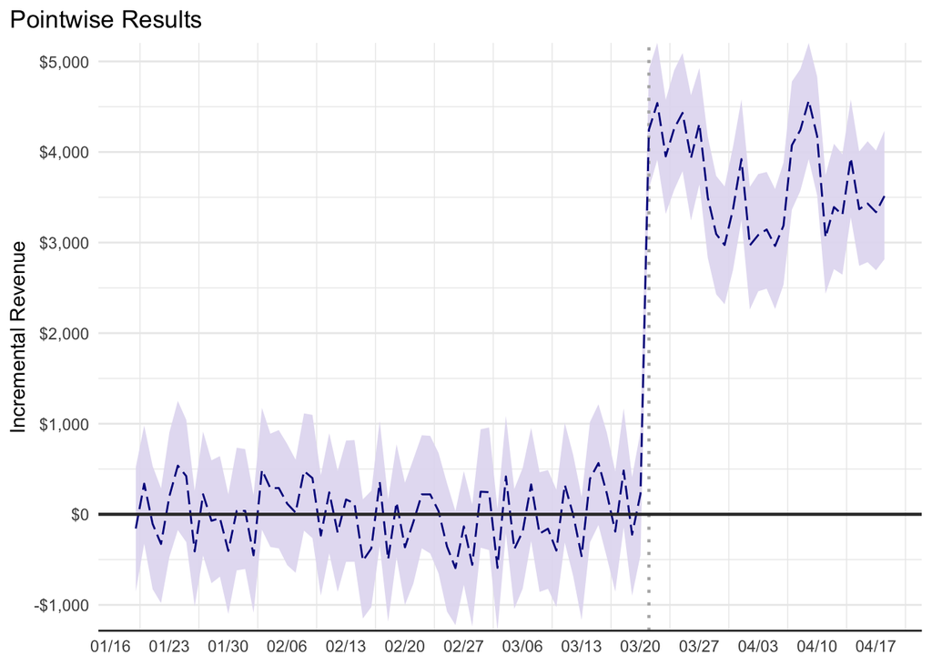

```r
gg_pointwise <- ggplot(df_output, aes(x = date)) +
  # Add the ribbon
  geom_ribbon(mapping = aes(ymin = point.effect.lower,
                            ymax = point.effect.upper),
              alpha = 0.9,
              fill = ribbon_color) +
  # Intervention line.
  geom_vline(mapping = aes(xintercept = impact$model$post.period[1]),
             color = int_line_color, linetype = int_line_type, linewidth = int_line_width) +
  # The prediction line (pointwise)
  geom_line(mapping = aes(y = point.effect, group=1),
            color = pred_line_color, linetype = pred_line_type) +
  # The "actual" for this plot is the baseline
  geom_hline(mapping = aes(yintercept=0), color = main_line_color,
             linewidth = main_line_width) +
  labs(title = "Pointwise Results", y = "Incremental Revenue") +
  scale_y_continuous(expand = c(0,0),
                     labels = dollar) +
  scale_x_date(date_breaks = "1 week", date_labels = "%m/%d") +
  theme_custom

gg_pointwise
```

At this point, the sky is really the limit, right? The visual can be endlessly tweaked for the specifics of the situation!

The repo for this post is at: github.com/gilliganondata/causalimpact-visuals.